# **Understanding Data Scientific process using AirBnB dataset**

### *05.03.2020*

# **Introduction**

In this post, I will be analyzing the AirBnB Dataset using visualizations and learning models. For analysis, I will follow the CRISP-DM process, on data from Valencia.

CRISP-DM

In working with missing values, categorical variables, and building out your model, it was probably easy to lose site of the big picture of the process. Let's take a quick recap about the work to be done in this research.

1. Business Understanding

   How do I break into the field? What are the placement and salaries of those who attended a coding bootcamp? How well can we predict an individual's salary? What aspects correlate well to salary? How well can we predict an individual's job satisfaction? What aspects correlate well to job satisfaction?
2. Data Understanding

   We were finally able to model the data, but we had some back and forth with step 3. before we were able to build a model that had okay performance. There still may be changes that could be done to improve the model we have in place. From additional feature engineering to choosing a more advanced modeling technique, we did little to test that other approaches were better within this lesson.
5. Results

   Results are the findings from our wrangling and modeling. They are the answers you found to each of the questions.
6. Deploy

   Deploying can occur by moving your approach into production or by using your results to persuade others within a company to act on the results. Communication is such an important part of the role of a data scientist.

#### Items to be done

1) Pick a dataset.

2) Pose at least three questions related to business or real-world applications of how the data could be used.

3) Create a Jupyter Notebook, using any associated packages you'd like, to:

```
Prepare data:
    Gather necessary data to answer your questions
    Handle categorical and missing data
    Provide insight into the methods you chose and why you chose them

Analyze, Model, and Visualize
    Provide a clear connection between your business questions and how the data answers them.
```

4) Communicate your business insights:

```
Create a Github repository to share your code and data wrangling/modeling techniques, with a technical audience in mind
Create a blog post to share your questions and insights with a non-technical audience
```

## Introduction

### Following are a few questions that we aim to answer through our analysis:

- How do prices of listings vary by location?
- How does the price varies according to older host from newer hosts?
- Can we predict the reccomended price, knowing the characteristics of a property?

**The project is available on Github**: [datascience blog](https://github.com/sanchezis/datascientist)

```python
import pandas as pd
import numpy as np
```

```python
import geopandas as gpd
```

```python
import os
import sys
```

```python
import seaborn as sns
```

```python
import datetime
```

```python
import json
import random
import re
import seaborn as sns
import time
import plotly

from IPython.core.display import display, HTML
display(HTML("<style>.container { width:100% !important; }</style>"))
display(HTML("<style>div.cell.selected {border-left-width: 1px !important;}</style>"))

#Ipython notebook settings
pd.set_option('max_info_columns', 500)
pd.set_option('max_colwidth',50)
pd.set_option('large_repr', 'info')
pd.set_option ('display.notebook_repr_html', True)

pd.set_option('expand_frame_repr', True)
#pd.set_option('display.html.table_schema', True)
pd.set_option('max_info_rows', 500)

pd.set_option('display.max_rows', None)
pd.set_option('display.max_columns', None)
pd.set_option('display.width', 10000)
pd.set_option('display.large_repr', 'truncate')
pd.options.display.float_format = '{:,.2f}'.format

import geopandas as gpn

from mpl_toolkits.basemap import Basemap
from mpl_toolkits import mplot3d

import descartes
from shapely.geometry import Point,Polygon

import warnings
warnings.filterwarnings('ignore')

warnings.filterwarnings("ignore", category=DeprecationWarning)
warnings.filterwarnings("ignore", category=FutureWarning)

def warn(*args, **kwargs):
    pass
warnings.warn = warn

import matplotlib.pyplot as plt
from mpl_toolkits import mplot3d
%matplotlib inline

%load_ext autoreload
%autoreload 2
```

```
The autoreload extension is already loaded. To reload it, use:
  %reload_ext autoreload
```

```python
from sklearn.model_selection import train_test_split
from sklearn.metrics import accuracy_score, f1_score
from sklearn.ensemble import RandomForestRegressor
from sklearn.decomposition import PCA
from sklearn.metrics import mean_squared_error, accuracy_score, median_absolute_error, mean_absolute_error
from sklearn.preprocessing import StandardScaler

import math
```

```python
from pandas.plotting import register_matplotlib_converters
register_matplotlib_converters()
```

```python
!ls data
```

```
listings.csv
neighbourhoods.csv
neighbourhoods.geojson
```

```python
listings = pd.read_csv('data\\listings.csv', encoding='utf-8')
neighbourhoods = pd.read_csv('data\\neighbourhoods.csv', encoding='utf-8')

# listings.host_since
listings.host_since = pd.to_datetime(listings['host_since'],infer_datetime_format=True,errors='coerce')
listings['price_f'] = listings.price.apply(lambda x: str(x).replace('$','').replace(',','')).astype(float)
listings.rename({'id':'listing_id'}, inplace=True, axis=1)
```

```python
neighbourhoods_geo = gpd.read_file('data\\neighbourhoods.geojson')

print(type(neighbourhoods_geo))
```

```
<class 'geopandas.geodataframe.GeoDataFrame'>
```

```python
import mplleaflet
import geoplot
import contextily as ctx
```

```python
sns.set(style='whitegrid', palette='pastel', color_codes=True)
sns.mpl.rc('figure', figsize=(10,6))
```

```python
from shapely.geometry import Point
plotly.offline.init_notebook_mode(connected=True)

listings['coords'] = list(zip(listings.longitude, listings.latitude))
```

> *you can run this, for an iterative map:*

> ```
> ax = neighbourhoods_geo.plot( figsize=(10,10)
>                         , colormap='Accent'
>                        );
> ```

> ```
> mplleaflet.display(fig=ax.figure,
>                    crs=neighbourhoods_geo.crs,
>                    tiles='cartodb_positron')
> ```

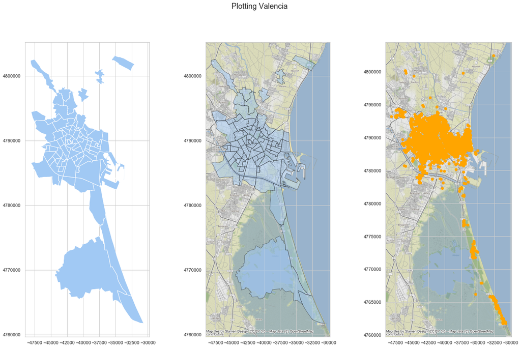

```python
fig , (ax,bx,cx)= plt.subplots(1,3, figsize=(22,13))

fig.suptitle('Plotting Valencia', fontsize=18)

neighbourhoods_geo.to_crs(epsg=3857).plot(ax=ax)    # , colormap='Accent',facecolor='grey', alpha=0.25, linewidth=0.1, color='green'

neighbourhoods_geo.to_crs(epsg=3857).plot(ax=bx,
                                          #figsize=(10, 10),
                                          alpha=0.5, edgecolor='k')
ctx.add_basemap(bx)

# ... turn them into geodataframe, and convert our
# epsg into 3857, since web map tiles are typically
# provided as such.
geo_df = gpd.GeoDataFrame(
    listings, crs  ={'init': 'epsg:4326'}, # 4326 ??
    geometry = listings['coords'].apply(Point)
).to_crs(epsg=3857)

# ... and make the plot
#cx =
geo_df.plot(
    ax=cx,
    #figsize= (15, 50),
    color= "orange",
    alpha  = 1
)
ctx.add_basemap(cx)
#cx.set_axis_off()

#plt.title('Plotting Valencia')
plt.savefig('val1.png')
plt.show()
```

## Description of Data

The data is sourced from the **[inside AirBnB](http://insideairbnb.com/get-the-data.html)** website which hosts publicly available data from the Airbnb site. The dataset comprises of three main tables:

- `listings` - Detailed listings data showing 106 atttributes for each of the listings. Some of the attributes used in the analysis are `price` (continuous), `longitude` (continuous), `latitude` (continuous), `listing_type` (categorical), `is_superhost` (categorical), `neighbourhood` (categorical), `ratings` (continuous) among others.
- `reviews` - Detailed reviews given by the guests with 6 attributes. Key attributes include `date` (datetime), `listing_id` (discrete), `reviewer_id` (discrete) and `comment` (textual).
- `calendar` - Provides details about booking for the next year by listing. Four attributes in total including `listing_id` (discrete), `date` (datetime), `available` (categorical) and `price` (continuous). A quick glance at the data shows that there are:
- 7194 unique listing in dataset in total. The first rental in the city was up in ' 3 Jan 2009'.
- Over a quarter of million reviews have been written by guests since then.
- The price for a listing ranges from \$9 per night to \\$8,000! per night.

Just for this simple purpose, we are only going to use `listings` and `neighbourhood` data.

```python
print ( """the size of dataset listings is {}  and first input value is from {}
the last input host is from {} and the size of the reviews is {}.     """ .format( listings.shape[0],
                                                                                        datetime.datetime.strftime( listings.host_since.min() ,'%e %h %Y')
                                                                                       ,listings.host_since.max()
                                                                                       ,reviews.shape[0]
                                                                                      ) )
```

```
the size of dataset listings is 7194  and first input value is from  3 Jan 2009
the last input host is from 2019-11-28 00:00:00 and the size of the reviews is 265051.
```

```python
print ( "minimum price is ${} and max ${:,}".format( listings.price_f.min(), listings.price_f.max() ) )
```

```
minimum price is $9.0 and max $8,000.0
```

## Explore the data

#### check the neighbourhood

```python
print(listings.neighbourhood_cleansed.value_counts().shape)
print(listings.neighbourhood_group_cleansed.value_counts().shape)
print()
print(neighbourhoods.neighbourhood.value_counts().shape)
print(neighbourhoods.neighbourhood_group.value_counts().shape)
print()
print(neighbourhoods_geo.neighbourhood.value_counts().shape)
print(neighbourhoods_geo.neighbourhood_group.value_counts().shape)
```

```
(85,)
(19,)

(88,)
(19,)

(88,)
(19,)
```

With this we can see that there are neighbourhoods that do not have any listing.

#### Lists of columns in dataset and show the type

```python
i=0
for e in listings.columns:
    sys.stdout.write("{:9s}: {:28s} ".format(str(listings[e].dtype),e))
    i+=1
    if i%4 ==0: sys.stdout.write("\n")
    if len(e)>28: sys.stdout.write("\n")
```

```
int64    : listing_id                   object   : listing_url                  int64    : scrape_id                    object   : last_scraped
object   : name                         object   : summary                      object   : space                        object   : description
object   : experiences_offered          object   : neighborhood_overview        object   : notes                        object   : transit
object   : access                       object   : interaction                  object   : house_rules                  float64  : thumbnail_url
float64  : medium_url                   object   : picture_url                  float64  : xl_picture_url               int64    : host_id
object   : host_url                     object   : host_name                    datetime64[ns]: host_since                   object   : host_location
object   : host_about                   object   : host_response_time           object   : host_response_rate           float64  : host_acceptance_rate
object   : host_is_superhost            object   : host_thumbnail_url           object   : host_picture_url             object   : host_neighbourhood
float64  : host_listings_count          float64  : host_total_listings_count    object   : host_verifications           object   : host_has_profile_pic
object   : host_identity_verified       object   : street                       object   : neighbourhood                object   : neighbourhood_cleansed
object   : neighbourhood_group_cleansed object   : city                         object   : state                        object   : zipcode
object   : market                       object   : smart_location               object   : country_code                 object   : country
float64  : latitude                     float64  : longitude                    object   : is_location_exact            object   : property_type
object   : room_type                    int64    : accommodates                 float64  : bathrooms                    float64  : bedrooms
float64  : beds                         object   : bed_type                     object   : amenities                    float64  : square_feet
object   : price                        object   : weekly_price                 object   : monthly_price                object   : security_deposit
object   : cleaning_fee                 int64    : guests_included              object   : extra_people                 int64    : minimum_nights
int64    : maximum_nights               int64    : minimum_minimum_nights       int64    : maximum_minimum_nights       int64    : minimum_maximum_nights
int64    : maximum_maximum_nights       float64  : minimum_nights_avg_ntm       float64  : maximum_nights_avg_ntm       object   : calendar_updated
object   : has_availability             int64    : availability_30              int64    : availability_60              int64    : availability_90
int64    : availability_365             object   : calendar_last_scraped        int64    : number_of_reviews            int64    : number_of_reviews_ltm
object   : first_review                 object   : last_review                  float64  : review_scores_rating         float64  : review_scores_accuracy
float64  : review_scores_cleanliness    float64  : review_scores_checkin        float64  : review_scores_communication  float64  : review_scores_location
float64  : review_scores_value          object   : requires_license             object   : license                      float64  : jurisdiction_names
object   : instant_bookable             object   : is_business_travel_ready     object   : cancellation_policy          object   : require_guest_profile_picture

object   : require_guest_phone_verification
int64    : calculated_host_listings_count
int64    : calculated_host_listings_count_entire_homes
int64    : calculated_host_listings_count_private_rooms

int64    : calculated_host_listings_count_shared_rooms
float64  : reviews_per_month            float64  : price_f                      object   : coords
geometry : geometry
```

```python
r=[]
d=[]
for e in listings.columns:
    if listings[e].dtype!='object':
        r.append(e)
    else:
        d.append(e)
```

```python
listings[r] [:5]
```

|  | listing_id | scrape_id | thumbnail_url | medium_url | xl_picture_url | host_id | host_since | host_acceptance_rate | host_listings_count | host_total_listings_count | latitude | longitude | accommodates | bathrooms | bedrooms | beds | square_feet | guests_included | minimum_nights | maximum_nights | minimum_minimum_nights | maximum_minimum_nights | minimum_maximum_nights | maximum_maximum_nights | minimum_nights_avg_ntm | maximum_nights_avg_ntm | availability_30 | availability_60 | availability_90 | … |
| --- | --- | --- | --- | --- | --- | --- | --- | --- | --- | --- | --- | --- | --- | --- | --- | --- | --- | --- | --- | --- | --- | --- | --- | --- | --- | --- | --- | --- | --- | --- |
| 0 | 4620 | 20191130195801 | nan | nan | nan | 7093832 | 2013-06-24 | nan | 3.00 | 3.00 | 39.48 | -0.32 | 8 | 2.00 | 4.00 | 6.00 | nan | 6 | 2 | 365 | 2 | 2 | 365 | 365 | 2.00 | 365.00 | 26 | 54 | 84 | … |
| 1 | 45528 | 20191130195801 | nan | nan | nan | 202104 | 2010-08-15 | nan | 1.00 | 1.00 | 39.36 | -0.32 | 6 | 1.00 | 2.00 | 3.00 | nan | 4 | 3 | 15 | 3 | 6 | 1125 | 1125 | 3.20 | 1,125.00 | 20 | 50 | 72 | … |
| 2 | 48154 | 20191130195801 | nan | nan | nan | 219476 | 2010-09-01 | nan | 2.00 | 2.00 | 39.49 | -0.37 | 4 | 1.50 | 2.00 | 2.00 | 700.00 | 2 | 3 | 15 | 3 | 3 | 15 | 15 | 3.00 | 15.00 | 27 | 57 | 87 | … |
| 3 | 55692 | 20191130195801 | nan | nan | nan | 120649 | 2010-05-08 | nan | 1.00 | 1.00 | 39.48 | -0.38 | 3 | nan | 1.00 | 1.00 | 65.00 | 3 | 1 | 730 | 1 | 1 | 730 | 730 | 1.00 | 730.00 | 0 | 0 | 0 | … |
| 4 | 95393 | 20191130195801 | nan | nan | nan | 508042 | 2011-04-14 | nan | 6.00 | 6.00 | 39.48 | -0.38 | 6 | 2.00 | 3.00 | 6.00 | nan | 4 | 1 | 14 | 1 | 2 | 14 | 14 | 1.30 | 14.00 | 0 | 0 | 0 | … |

```python
listings[d] [:5]
```

|  | listing_url | last_scraped | name | summary | space | description | experiences_offered | neighborhood_overview | notes | transit | access | interaction | house_rules | picture_url | host_url | host_name | host_location | host_about | host_response_time | host_response_rate | host_is_superhost | host_thumbnail_url | host_picture_url | host_neighbourhood | host_verifications | host_has_profile_pic | host_identity_verified | street | neighbourhood | … |
| --- | --- | --- | --- | --- | --- | --- | --- | --- | --- | --- | --- | --- | --- | --- | --- | --- | --- | --- | --- | --- | --- | --- | --- | --- | --- | --- | --- | --- | --- | --- |
| 0 | https://www.airbnb.com/rooms/4620 | 2019-11-30 | VALENCIA HISTORIC HOUSE 50M BEACH | Casa a 50 m de la playa,fachada del siglo XIX,... | 1920 HISTORIC house passed down by generations... | Casa a 50 m de la playa,fachada del siglo XIX,... | none | Tipico barrio valenciano al lado de la playa. ... | La casa esta provista de calefaccion y aire ac... | Existe transporte publico a escasos metros de ... | Disponemos de guia turistico en la ciudad como... | Lo necesario | No fumar, existen espacios exteriores que podr... | https://a0.muscache.com/im/pictures/82685026/a... | https://www.airbnb.com/users/show/7093832 | Francisca | Valencia, Valencian Community, Spain | My name is Paqui and I am from Madrid. I have... | within an hour | 100% | f | https://a0.muscache.com/im/users/7093832/profi... | https://a0.muscache.com/im/users/7093832/profi... | NaN | ['email', 'phone', 'reviews', 'jumio', 'govern... | t | t | Valencia, Valencian Community, Spain | Poblados Marítimos | … |
| 1 | https://www.airbnb.com/rooms/45528 | 2019-12-01 | Valencia: El Saler Beach and Albufera Lake | Ideal for relaxing with your family in the bea... | Near to the beach, near to the city. Come with... | Ideal for relaxing with your family in the bea... | none | The neighbourhood are Spanish famillies with c... | We accept dogs for free. | It is better you come with your car. | From Valencia city, from city of Science, CV 5... | I like to share experiences with my hosts. It ... | RESERVA INMEDIATA: Antes de hacer la reserva e... | https://a0.muscache.com/im/pictures/9660365/c6... | https://www.airbnb.com/users/show/202104 | Lidia | Spain | Je parle français.\r\n I can speak English.\r\... | within a few hours | 100% | f | https://a0.muscache.com/im/users/202104/profil... | https://a0.muscache.com/im/users/202104/profil... | NaN | ['email', 'phone', 'reviews', 'jumio', 'govern... | t | t | València, Comunitat Valenciana, Spain | NaN | … |
| 2 | https://www.airbnb.com/rooms/48154 | 2019-11-30 | beautiful apartment wifi | Segundo piso en una finca de finales del siglo... | Hello everybody and thank you for your interes... | Hello everybody and thank you for your interes... | none | Barrio muy cercano al cassco historico de la c... | NaN | Autobuses lineas (Phone number hidden by Airbn... | Todo el piso completo para vosotros | NaN | Ser respetuosos con vuestra casa de vacaciones... | https://a0.muscache.com/im/pictures/1109085/9c... | https://www.airbnb.com/users/show/219476 | Toni | spain | Un saludo a todos. Espero que os pongáis en co... | within an hour | 90% | f | https://a0.muscache.com/im/users/219476/profil... | https://a0.muscache.com/im/users/219476/profil... | NaN | ['email', 'phone', 'reviews', 'jumio', 'govern... | t | t | Valencia, Valencia, Spain | La Saïdia | … |
| 3 | https://www.airbnb.com/rooms/55692 | 2019-12-01 | Delight in city center | A great place to stay and visit Valencia. | Hello everybody and thank you very much for sh... | A great place to stay and visit Valencia. Hell... | none | NaN | NaN | NaN | NaN | NaN | NaN | https://a0.muscache.com/im/pictures/329316/a5d... | https://www.airbnb.com/users/show/120649 | Pilar | Valencia, Valenciana, Spain | We are a couple from Spain, no kids, no pets, ... | within an hour | 100% | f | https://a0.muscache.com/im/users/120649/profil... | https://a0.muscache.com/im/users/120649/profil... | NaN | ['email', 'phone', 'reviews', 'jumio', 'govern... | t | t | Valencia, Valencian Community, Spain | Ciutat Vella | … |
| 4 | https://www.airbnb.com/rooms/95393 | 2019-12-01 | Modern and bright Duplex 3 Bedrooms Center Wi-Fi | This is "Edificio Palomar Apartments", I will ... | Located right in the Historical Centre you can... | This is "Edificio Palomar Apartments", I will ... | none | It is just 10 min walking distance to the Cath... | Registro: UAT-Nº 31815 | Public transport is available to reach the bea... | Lift access and fully equipped: - 2 complete b... | Reception is open from 9 till 15h (monday-frid... | Let me know arrival details (ETA) to arrange c... | https://a0.muscache.com/im/pictures/931683/64a... | https://www.airbnb.com/users/show/508042 | Carmen | Valencia, Valencia, Spain | Nice to meet you. I´m valencian and love my jo... | within a few hours | 100% | f | https://a0.muscache.com/im/pictures/user/ba968... | https://a0.muscache.com/im/pictures/user/ba968... | Ciutat Vella | ['email', 'phone', 'facebook', 'reviews', 'jum... | t | t | Valencia, Valenciana, Spain | Ciutat Vella | … |

```python
neighbourhoods[:5]
```

|  | neighbourhood_group | neighbourhood |
| --- | --- | --- |
| 0 | ALGIROS | CIUTAT JARDI |
| 1 | ALGIROS | LA CARRASCA |
| 2 | ALGIROS | L'AMISTAT |
| 3 | ALGIROS | LA VEGA BAIXA |
| 4 | ALGIROS | L'ILLA PERDUDA |

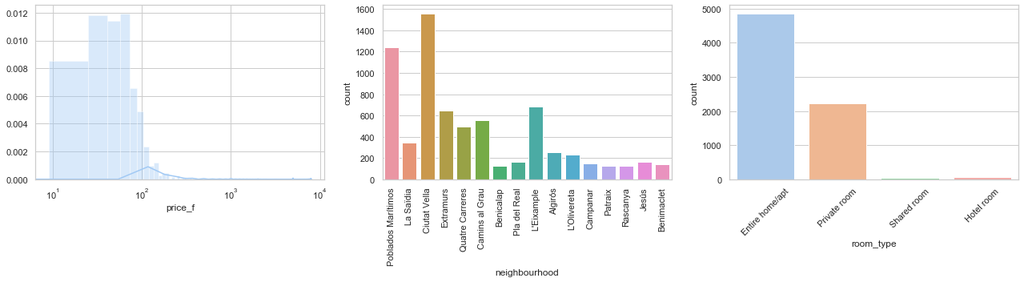

```python
plt.figure(figsize=(22,4))
plt.subplot(1,3,1);
g = sns.distplot(listings['price_f'],bins=500);
g.set_xscale('log')

plt.subplot(1,3,2);
g = sns.countplot(x='neighbourhood', data=listings);
g.set_xticklabels(g.get_xticklabels(), rotation=90);

plt.subplot(1,3,3);
g = sns.countplot(x='room_type', data=listings);
g.set_xticklabels(g.get_xticklabels(), rotation=45);
plt.savefig('val2.png')
```

> From the full data set only some has true coordinates, so we will discard the ones that dont have proper coordinate settings:

```python
listings.is_location_exact.value_counts()
```

```
t    4282
f    2912
Name: is_location_exact, dtype: int64
```

```python
listings = listings [ (listings.is_location_exact=='t') ]
```

```python
listings.shape
```

```
(4282, 109)
```

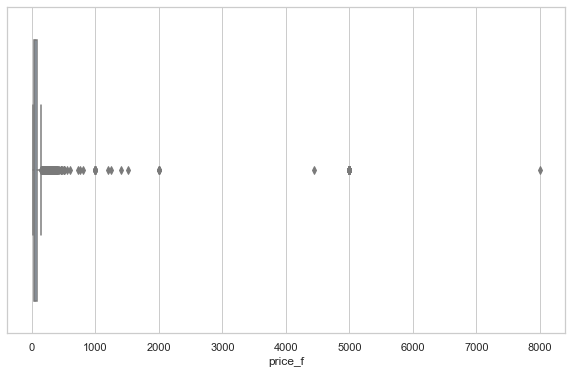

```python
sns.boxplot(listings.price_f)
plt.savefig('val3.png')
```

# Preparing the Data

To be able to answer our questions, we need to prepare the dataset, by cleaning missing values by removing or imputing them, joining the datasets together, and encoding categorical columns.

```python
listings = listings[listings.price_f<=180]
```

```python
listings_id = ['listing_id']

listings_categorical_cols = [ 'host_since',  'host_is_superhost', 'host_identity_verified',
                            'street','neighbourhood_cleansed',	'neighbourhood_group_cleansed',	'city',
                            'latitude', 'longitude',
                             'zipcode',	'market',	'smart_location',	'country_code',	'country', 'property_type',
                            'room_type', 'bed_type', 'requires_license',	'coords',	'geometry']

listings_numerical_cols = ['bathrooms', 'bedrooms', 'beds', 'accommodates', 'square_feet','guests_included','number_of_reviews','minimum_nights', 'maximum_nights',
                           'price_f']

listings_cols = listings_id +listings_categorical_cols+listings_numerical_cols

listings = listings[listings_cols]
```

```python
df = pd.DataFrame(listings[listings_categorical_cols+listings_numerical_cols].isnull().sum(), columns=["sum"])
df['rate'] = df['sum'] / listings.shape[0]
display(HTML('<h3>columns that are completely empty</h3>'))
display(df[df.rate==1.0])
listing_missing = df[df.rate==1.0].index
listing_full = df[df.rate<=0.3].index

display(HTML('<h4>we save them under listing_missing_gr_05</h4>'))
listing_missing_gr_05 = df[df.rate > 0.5].index
display(df[df.rate > 0.5])

display(HTML('<h4>we save them under listing_missing_gr_03</h4>'))
listing_missing_gr_03 = df[df.rate > 0.3].index
display(df[(df.rate > 0.3) & (df.rate <= 0.5)])
del df
```

columns that are completely empty

|  | sum | rate |
| --- | --- | --- |

we save them under listing_missing_gr_05

|  | sum | rate |
| --- | --- | --- |
| square_feet | 4049 | 0.98 |

we save them under listing_missing_gr_03

|  | sum | rate |
| --- | --- | --- |

We suppose that at least all nan has no bathrooms

```python
listings.bathrooms.fillna(0, inplace=True)
```

```python
cols = ['property_type',	'room_type',	'bed_type',	'bathrooms',	'bedrooms',	'beds',	'square_feet']

sq_analysis = listings[cols]    [(~listings.square_feet.isnull()) & (listings.square_feet>0)]
```

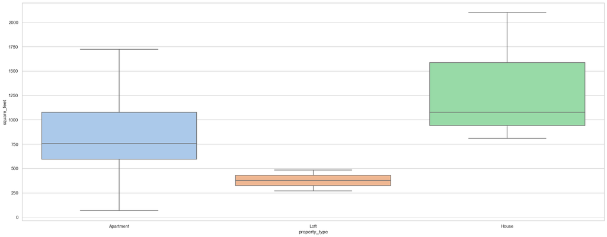

```python
fig, (ax) = plt.subplots(1,1,figsize=(26,10))

sns.boxplot( x='property_type',y='square_feet',  data=sq_analysis[['property_type','square_feet']], ax=ax)
#sns.boxplot( x='room_type',y='square_feet',  data=sq_analysis[['room_type','square_feet']], ax=bx)
plt.savefig('val4.png')
```

We are going to use property_type median for filling the np.nan and 0 in feature square_feet so that we can reutilize the full amount of the dataset.  
In other occasion we could drop this values, but in this case it is removing quite many rows in data.

```python
display(sq_analysis.groupby(['room_type']).agg({'mean'})['square_feet'])
display(sq_analysis.groupby(['property_type']).agg({'median'})['square_feet'])
```

| room_type | mean |
| --- | --- |
| Entire home/apt | 842.26 |
| Private room | 586.62 |

| property_type | median |
| --- | --- |
| Apartment | 753.00 |
| House | 1,076.00 |
| Loft | 376.50 |

```python
listings = listings [listings. property_type.isin( sq_analysis.groupby(['property_type']).agg({'median'})['square_feet'].index.to_list())]
```

```python
listings= pd.merge(
    listings,
    listings[(~listings.square_feet.isnull()) & (listings.square_feet>0)].groupby(['property_type']).agg({'median'})['square_feet'],
    left_on='property_type',
    right_on='property_type',
    how='left',
    sort=False
)
listings['square_feet'][(listings.square_feet.isnull()) | (listings.square_feet==0)] = listings['median']
listings.drop('median',axis=1, inplace=True)
```

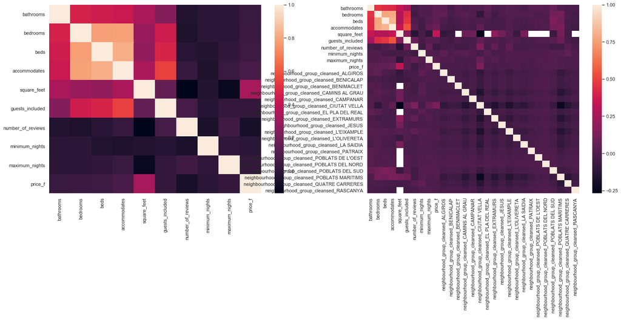

```python
fig , (ax1,ax2) = plt.subplots(1,2,figsize=(24,8))

sns.heatmap(listings[listings_numerical_cols].corr(), ax=ax1)

sns.heatmap(pd.concat ( [listings[listings_numerical_cols], pd.get_dummies( listings[[ 'neighbourhood_group_cleansed']] ) ], axis=1).corr(), ax=ax2)
plt.savefig('val5.png')
```

> it is obvious we can add to this analysis the categorical neighbourhood_group_cleansed which of course it influences the price. we can see that the  
> neigbourhood of 'Ciutat Vella', 'poblats maritims' has different price values. The reason looks pretty turistical. (graph on the right)

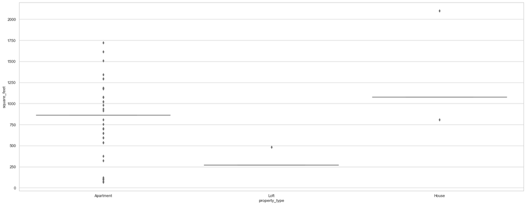

```python
fig, (ax) = plt.subplots(1,1,figsize=(26,10))

sns.boxplot( x='property_type',y='square_feet',  data=listings[['property_type','square_feet']],order=["Apartment", "Loft", 'House'], ax=ax)
#sns.boxplot( x='room_type',y='square_feet',  data=sq_analysis[['room_type','square_feet']], ax=bx)
plt.savefig('val6.png')
```

```python
listings.isnull().sum().all()
```

```
False
```

```python
print(listings.shape)
listings.dropna(inplace=True)
print(listings.shape)
```

```
(3866, 31)
(3799, 31)
```

## Question 1.

How do prices of listings vary by location?

```python
listings.groupby(['neighbourhood_group_cleansed','neighbourhood_cleansed']).agg({'mean','median','max','min'})['price_f'].sort_values('mean', ascending=False)[:5]
```

| neighbourhood_group_cleansed | neighbourhood_cleansed | min | mean | max | median |
| --- | --- | --- | --- | --- | --- |
| POBLATS DEL SUD | EL SALER | 32.00 | 89.44 | 180.00 | 79.50 |
| CIUTAT VELLA | LA XEREA | 23.00 | 89.25 | 180.00 | 79.00 |
| L'EIXAMPLE | EL PLA DEL REMEI | 25.00 | 87.92 | 180.00 | 75.00 |
| CIUTAT VELLA | LA SEU | 29.00 | 77.40 | 180.00 | 70.00 |
| QUATRE CARRERES | LA PUNTA | 42.00 | 72.40 | 150.00 | 50.00 |

[figure not shown]

```python
fig , (ax)= plt.subplots(1,1, figsize=(22,13))

fig.suptitle('Top 5 most expensive neighbours', fontsize=18)

neighbourhoods_geo.to_crs(epsg=3857).plot(ax=ax,
                                          alpha=0.35,
                                          edgecolor='k'
                                         )
neighbourhoods_geo[neighbourhoods_geo.neighbourhood.isin(neighbourhoods[neighbourhoods.neighbourhood.isin(['RAFALELL-VISTABELLA','LA XEREA','EL SALER','EL PLA DEL REMEI'
                                                                                                                 ,'EL PERELLONET'
                                                                                                                #,'LA SEU' ,'LA PUNTA'
                                                                                                                ])].neighbourhood)] \
                                    .to_crs(epsg=3857).plot(ax=ax,
                                          alpha=0.5,
                                          edgecolor='k',
                                        color='orange'
                                         )
ctx.add_basemap(ax)
plt.savefig('val7.png')
```

## Question 2.

How does the price varies according to older host from newer hosts?

```python
df = listings.groupby(['host_since','neighbourhood_group_cleansed']).agg({'mean', 'min', 'max'}).sort_index() ['price_f']
df[:30]
```

| host_since | neighbourhood_group_cleansed | min | mean | max |
| --- | --- | --- | --- | --- |
| 2009-01-03 | POBLATS MARITIMS | 37.00 | 37.00 | 37.00 |
| 2009-06-23 | QUATRE CARRERES | 20.00 | 20.00 | 20.00 |
| 2010-05-06 | CAMPANAR | 35.00 | 35.00 | 35.00 |
| 2010-05-08 | CIUTAT VELLA | 100.00 | 100.00 | 100.00 |
| 2010-05-16 | POBLATS MARITIMS | 36.00 | 36.00 | 36.00 |
| 2010-06-08 | ALGIROS | 79.00 | 79.00 | 79.00 |
|  | EL PLA DEL REAL | 28.00 | 36.00 | 45.00 |
| 2010-07-09 | EXTRAMURS | 18.00 | 18.00 | 18.00 |
| 2010-07-29 | CIUTAT VELLA | 63.00 | 63.00 | 63.00 |
| 2010-09-01 | LA SAIDIA | 45.00 | 50.00 | 55.00 |
| 2010-12-25 | POBLATS MARITIMS | 55.00 | 55.00 | 55.00 |
| 2011-01-14 | CIUTAT VELLA | 34.00 | 36.00 | 38.00 |
| 2011-02-01 | CIUTAT VELLA | 75.00 | 80.00 | 85.00 |
| 2011-03-06 | EL PLA DEL REAL | 85.00 | 85.00 | 85.00 |
| 2011-03-09 | CIUTAT VELLA | 42.00 | 42.00 | 42.00 |
|  | EXTRAMURS | 25.00 | 60.00 | 95.00 |
| 2011-03-13 | POBLATS MARITIMS | 49.00 | 54.00 | 59.00 |
| 2011-03-14 | EXTRAMURS | 68.00 | 68.00 | 68.00 |
| 2011-03-22 | LA SAIDIA | 50.00 | 50.00 | 50.00 |
| 2011-03-25 | CIUTAT VELLA | 62.00 | 62.00 | 62.00 |
| 2011-03-29 | EXTRAMURS | 33.00 | 38.00 | 43.00 |
| 2011-04-14 | CIUTAT VELLA | 55.00 | 101.75 | 134.00 |
| 2011-04-22 | L'EIXAMPLE | 80.00 | 80.00 | 80.00 |
| 2011-04-26 | CAMINS AL GRAU | 150.00 | 150.00 | 150.00 |
| 2011-05-12 | CIUTAT VELLA | 15.00 | 15.00 | 15.00 |
| 2011-05-15 | CAMINS AL GRAU | 55.00 | 55.00 | 55.00 |
|  | CIUTAT VELLA | 80.00 | 80.00 | 80.00 |
|  | EXTRAMURS | 55.00 | 55.00 | 55.00 |
| 2011-05-20 | CIUTAT VELLA | 39.00 | 39.00 | 39.00 |
| 2011-05-21 | POBLATS MARITIMS | 24.00 | 24.00 | 24.00 |

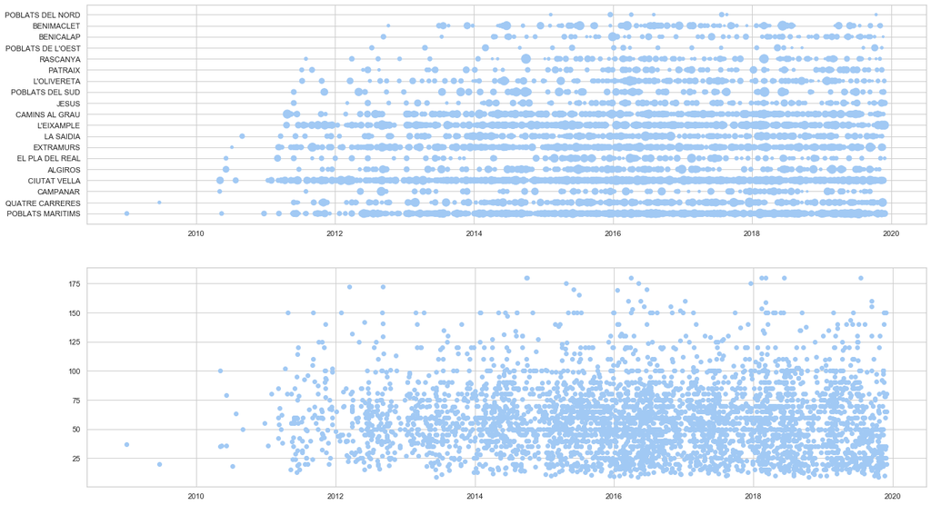

```python
fig , (ax, bx)= plt.subplots(2,1, figsize=(22,13))
ax.scatter( df.index.get_level_values(0), df.index.get_level_values(1) , s= df['mean'])
bx.scatter(  df.index.get_level_values(0), y=df['mean'])

plt.savefig('val8.png')
```

# Modelling

## Question 3.

Can we predict the reccomended price, knowing the characteristics of a property?

With cleaned and processed data, we can now go ahead to the next step in the CRISP-DM process, Modeling. Let’s define our problem statement, what we are trying to predict, and how we tend to achieve it.

Problem Statement: *Which attributes influence price, and how relevant are they to it?*

What we are predicting: *Price for a listing.*

First, we divide the data into X and Y, along with a Train-Test Split. We then train it on a model and predict values on it. For regression, we will use the RandomForestRegressor, because it is an ensemble technique. With the large number of attributes we have, training multiple trees will give a good average of multiple training tests.

```python
from sklearn.ensemble import RandomForestRegressor

from sklearn.metrics import mean_squared_error, mean_absolute_error,explained_variance_score
from sklearn.metrics import accuracy_score,precision_score, recall_score, roc_auc_score

from sklearn.model_selection import train_test_split

from sklearn.model_selection import KFold
from sklearn.preprocessing import MinMaxScaler
from sklearn.svm import SVR
from sklearn.model_selection import cross_val_predict,cross_val_score
from matplotlib.colors import ListedColormap

from sklearn.preprocessing import StandardScaler
#from sklearn.datasets import make_moons, make_circles, make_classification
from sklearn.neural_network import MLPClassifier, MLPRegressor
from sklearn.neighbors import KNeighborsClassifier
from sklearn.svm import SVC
from sklearn.gaussian_process import GaussianProcessClassifier
from sklearn.gaussian_process.kernels import RBF
#from sklearn.tree import DecisionTreeClassifier
#from sklearn.ensemble import RandomForestClassifier, AdaBoostClassifier
from sklearn.naive_bayes import GaussianNB
from sklearn.discriminant_analysis import QuadraticDiscriminantAnalysis
from sklearn.preprocessing import QuantileTransformer
```

```python
from sklearn.metrics import r2_score


def performance_metric(y_true, y_pred):
    """ Calculates and returns the performance score between
        true and predicted values based on the metric chosen. """
    score = r2_score(y_true, y_pred)
    return score
```

```python
features_cols = ['neighbourhood_group_cleansed', 'property_type',	'room_type',	'bed_type',	'bathrooms',	'bedrooms',	'beds',	'accommodates',	'square_feet',	'guests_included',	'number_of_reviews',	'minimum_nights',	'maximum_nights']
target_col=['price_f']
```

```python
master = pd.get_dummies( listings[features_cols] )
label = listings[target_col]
```

```python
%%time

scaler =  QuantileTransformer(output_distribution='normal') # MinMaxScaler(feature_range=(0,1))
master_x = scaler.fit_transform(master)


scores = []

X = pd.DataFrame(master_x)
y = label

reg = RandomForestRegressor(
                n_jobs=2,
                random_state=100,
                n_estimators=200,
                oob_score= True,
                warm_start=True,
                max_depth=10
            )#,max_features=200)

for e in range(19,5,-1):
    if X.shape[0] % e == 0: break
print("Kfold in {} groups".format(e) )

cv = KFold(n_splits=e, random_state=42, shuffle=False)
for train_index, test_index in cv.split(X):
    sys.stdout.write("Train Index: {:30s} \n\r".format(str( train_index)[:30] ) )
    sys.stdout.write("Test Index: {:30s} \n\r".format(str(test_index)[:30] ) )

    X_train, X_test, y_train, y_test = X.iloc[train_index], X.iloc[test_index], y.iloc[train_index], y.iloc[test_index]
    reg.fit(X_train, y_train)
    scores.append(reg.score(X_test, y_test))

print(np.mean(scores))
```

```
Kfold in 6 groups
Train Index: [ 634  635  636 ... 3796 3797
Test Index: [  0   1   2   3   4   5   6
Train Index: [   0    1    2 ... 3796 3797
Test Index: [ 634  635  636  637  638  639
Train Index: [   0    1    2 ... 3796 3797
Test Index: [1267 1268 1269 1270 1271 1272
Train Index: [   0    1    2 ... 3796 3797
Test Index: [1900 1901 1902 1903 1904 1905
Train Index: [   0    1    2 ... 3796 3797
Test Index: [2533 2534 2535 2536 2537 2538
Train Index: [   0    1    2 ... 3163 3164
Test Index: [3166 3167 3168 3169 3170 3171
0.712796938257366
Wall time: 2.52 s
```

## Results

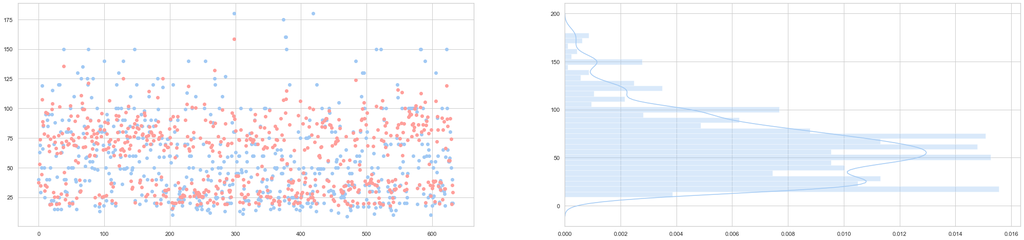

```python
fig, ax = plt.subplots(1, 2, sharey=True,   figsize=(35, 8))
plt.subplot(1, 2, 1)
plt.plot(y_test.values, 'bo') # plotting t, a separately
plt.plot(reg.predict(X_test).tolist(), 'ro') # plotting t, b separately

plt.subplot(1, 2, 2)
sns.distplot(label, vertical=True)
#p1 = sns.boxplot(label, vert=False)
plt.show()

plt.savefig('val9.png')
## blue dots :  actual target (y)
## red dots  : prediction TO that target
```

```python
sys.stdout.write("r2_score {:2}\n".format(  performance_metric(y_true = y_test, y_pred = reg.predict(X_test)) ))
sys.stdout.write("mean_squared_error {:2}\n".format(  mean_squared_error(y_true = y_test, y_pred = reg.predict(X_test)) ))
sys.stdout.write("mean_absolute_error {:2}\n".format(  mean_absolute_error(y_true = y_test, y_pred = reg.predict(X_test)) ))
sys.stdout.write("explained_variance_score {:2}\n".format(  explained_variance_score(y_true = y_test, y_pred = reg.predict(X_test)) ))


# reg.fit(X_train,y_train)
reg.score(X_test,y_test)

clf_regressor_prediction = reg.predict(X_test)
np.histogram(clf_regressor_prediction)

imp_regressor_df = pd.DataFrame(list(zip(X_train.columns,reg.feature_importances_)), columns=['feature', 'feature_weight'])
#print(imp_df.sort_values('importance', ascending=False)[:200])
pd.set_option('display.max_rows', 100)
print(imp_regressor_df[imp_regressor_df['feature_weight'] > 0.009].sort_values('feature_weight',ascending=False))
pd.set_option('display.max_rows', 10)
```

```
r2_score 0.7605851496143872
mean_squared_error 286.9394854038397
mean_absolute_error 12.414047530494631
explained_variance_score 0.7661724487964331
    feature  feature_weight
31       31            0.47
6         6            0.12
0         0            0.09
3         3            0.07
8         8            0.04
7         7            0.04
2         2            0.03
5         5            0.03
1         1            0.02
14       14            0.02
18       18            0.01
```

```python
print (master.iloc[:,31].name)
print (master.iloc[:,6].name)
print (master.iloc[:,0].name)
print (master.iloc[:,3].name)
print (master.iloc[:,8].name)
print (master.iloc[:,7].name)
print (master.iloc[:,2].name)
print (master.iloc[:,5].name)
print (master.iloc[:,1].name)
```

```
room_type_Entire home/apt
number_of_reviews
bathrooms
accommodates
maximum_nights
minimum_nights
beds
guests_included
bedrooms
```

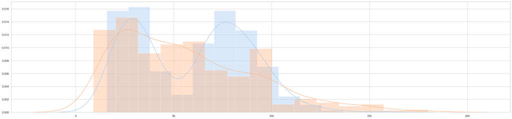

```python
fig, ax = plt.subplots(1, 1, sharey=True,   figsize=(35, 8))
sns.distplot(pd.DataFrame(reg.predict(X_test).tolist()), vertical=False, ax=ax)
sns.distplot(y_test, vertical=False, ax=ax)
plt.savefig('val10.png')
```

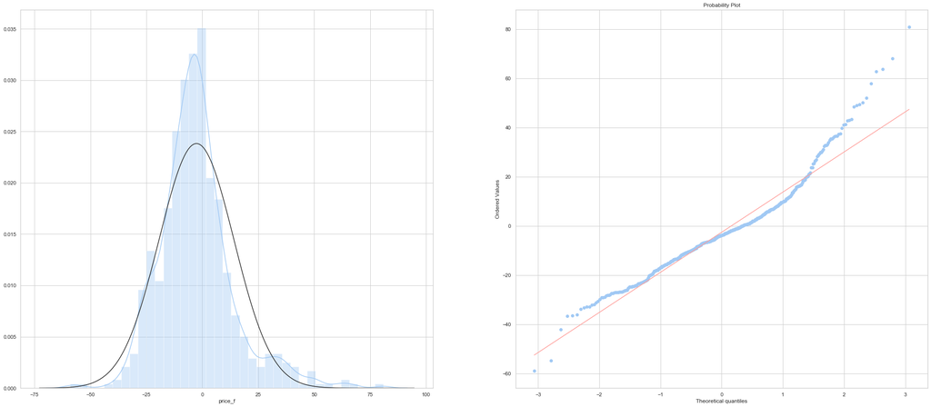

```python
predictions = reg.predict(X_test) #.tolist()
ResidualErrors =(y_test.price_f - predictions)

'''RANDOM REGRESSOR Residual Error Plots '''
from statsmodels.graphics.gofplots import qqplot
from scipy.stats import norm
from scipy import stats

fig=plt.figure(figsize=(35,15))
ax = plt.subplot(121)
bx = plt.subplot(122)
sns.distplot(ResidualErrors,fit=norm,ax=ax);
res = stats.probplot(ResidualErrors, plot=bx) # qqplot(ResidualErrors)

plt.savefig('val11.png')
plt.show()
```

### Contributions

We can from here predict a values using a line from the X_test and fill it with some data at will.

For this project, only my contribution was provided and I could made this report using the learned techniques from different data Scientist blogs and papers.

Different plots were needed to be shown to see the progress of the work done.